# Project Python Foundations: FoodHub Data Analysis

**Marks: 60**

### Context

The number of restaurants in New York is increasing day by day. Lots of students and busy professionals rely on those restaurants due to their hectic lifestyles. Online food delivery service is a great option for them. It provides them with good food from their favorite restaurants. A food aggregator company FoodHub offers access to multiple restaurants through a single smartphone app.

The app allows the restaurants to receive a direct online order from a customer. The app assigns a delivery person from the company to pick up the order after it is confirmed by the restaurant. The delivery person then uses the map to reach the restaurant and waits for the food package. Once the food package is handed over to the delivery person, he/she confirms the pick-up in the app and travels to the customer's location to deliver the food. The delivery person confirms the drop-off in the app after delivering the food package to the customer. The customer can rate the order in the app. The food aggregator earns money by collecting a fixed margin of the delivery order from the restaurants.

### Objective

The food aggregator company has stored the data of the different orders made by the registered customers in their online portal. They want to analyze the data to get a fair idea about the demand of different restaurants which will help them in enhancing their customer experience. Suppose you are hired as a Data Scientist in this company and the Data Science team has shared some of the key questions that need to be answered. Perform the data analysis to find answers to these questions that will help the company to improve the business.

### Data Description

The data contains the different data related to a food order. The detailed data dictionary is given below.

### Data Dictionary

- order_id: Unique ID of the order
- customer_id: ID of the customer who ordered the food
- restaurant_name: Name of the restaurant
- cuisine_type: Cuisine ordered by the customer
- cost: Cost of the order
- day_of_the_week: Indicates whether the order is placed on a weekday or weekend (The weekday is from Monday to Friday and the weekend is Saturday and Sunday)
- rating: Rating given by the customer out of 5
- food_preparation_time: Time (in minutes) taken by the restaurant to prepare the food. This is calculated by taking the difference between the timestamps of the restaurant's order confirmation and the delivery person's pick-up confirmation.
- delivery_time: Time (in minutes) taken by the delivery person to deliver the food package. This is calculated by taking the difference between the timestamps of the delivery person's pick-up confirmation and drop-off information

### Let us start by importing the required libraries

```python
# import libraries for data manipulation
import numpy as np
import pandas as pd

# import libraries for data visualization
import matplotlib.pyplot as plt
import seaborn as sns
```

### Understanding the structure of the data

```python
# read the data
df = pd.read_csv("C:/Users/USER/OneDrive/Desktop/DSBA/ClassWork/foodhub_order_data.csv")
# returns the first 5 rows
df.head()
```

|  | order_id | customer_id | restaurant_name | cuisine_type | cost_of_the_order | day_of_the_week | rating | food_preparation_time | delivery_time |
| --- | --- | --- | --- | --- | --- | --- | --- | --- | --- |
| 0 | 1477147 | 337525 | Hangawi | Korean | 30.75 | Weekend | Not given | 25 | 20 |
| 1 | 1477685 | 358141 | Blue Ribbon Sushi Izakaya | Japanese | 12.08 | Weekend | Not given | 25 | 23 |
| 2 | 1477070 | 66393 | Cafe Habana | Mexican | 12.23 | Weekday | 5 | 23 | 28 |
| 3 | 1477334 | 106968 | Blue Ribbon Fried Chicken | American | 29.20 | Weekend | 3 | 25 | 15 |
| 4 | 1478249 | 76942 | Dirty Bird to Go | American | 11.59 | Weekday | 4 | 25 | 24 |

#### Observations:

The DataFrame has 9 columns as mentioned in the Data Dictionary. Data in each row corresponds to the order placed by a customer.

### **Question 1:** How many rows and columns are present in the data? [0.5 mark]

```python
df.shape #returns the number of rows and columns in the data
```

```
(1898, 9)
```

#### Observations:

There are 1898 rows and 9 columns present in the data.

### **Question 2:** What are the datatypes of the different columns in the dataset? (The info() function can be used) [0.5 mark]

```python
# Use info() to print a concise summary of the DataFrame
df.info()
```

```
<class 'pandas.core.frame.DataFrame'>
RangeIndex: 1898 entries, 0 to 1897
Data columns (total 9 columns):
 #   Column                 Non-Null Count  Dtype
---  ------                 --------------  -----
 0   order_id               1898 non-null   int64
 1   customer_id            1898 non-null   int64
 2   restaurant_name        1898 non-null   object
 3   cuisine_type           1898 non-null   object
 4   cost_of_the_order      1898 non-null   float64
 5   day_of_the_week        1898 non-null   object
 6   rating                 1898 non-null   object
 7   food_preparation_time  1898 non-null   int64
 8   delivery_time          1898 non-null   int64
dtypes: float64(1), int64(4), object(4)
memory usage: 133.6+ KB
```

#### Observations:

There are THREE datatypes present in the data and these include: integer(int64), object and float(float64).

### **Question 3:** Are there any missing values in the data? If yes, treat them using an appropriate method. [1 mark]

```python
df.isnull().sum() # returns the number of missing values for each column in the data.
```

```
order_id                 0
customer_id              0
restaurant_name          0
cuisine_type             0
cost_of_the_order        0
day_of_the_week          0
rating                   0
food_preparation_time    0
delivery_time            0
dtype: int64
```

#### Observations:

There are NO missing values in the data hence no treatment required.

### **Question 4:** Check the statistical summary of the data. What is the minimum, average, and maximum time it takes for food to be prepared once an order is placed? [2 marks]

```python
df.describe(include='all').T #return and include all the columns in the statistical summary.
```

|  | count | unique | top | freq | mean | std | min | 25% | 50% | 75% | max |
| --- | --- | --- | --- | --- | --- | --- | --- | --- | --- | --- | --- |
| order_id | 1898.0 | NaN | NaN | NaN | 1477495.5 | 548.049724 | 1476547.0 | 1477021.25 | 1477495.5 | 1477969.75 | 1478444.0 |
| customer_id | 1898.0 | NaN | NaN | NaN | 171168.478398 | 113698.139743 | 1311.0 | 77787.75 | 128600.0 | 270525.0 | 405334.0 |
| restaurant_name | 1898 | 178 | Shake Shack | 219 | NaN | NaN | NaN | NaN | NaN | NaN | NaN |
| cuisine_type | 1898 | 14 | American | 584 | NaN | NaN | NaN | NaN | NaN | NaN | NaN |
| cost_of_the_order | 1898.0 | NaN | NaN | NaN | 16.498851 | 7.483812 | 4.47 | 12.08 | 14.14 | 22.2975 | 35.41 |
| day_of_the_week | 1898 | 2 | Weekend | 1351 | NaN | NaN | NaN | NaN | NaN | NaN | NaN |
| rating | 1898 | 4 | Not given | 736 | NaN | NaN | NaN | NaN | NaN | NaN | NaN |
| food_preparation_time | 1898.0 | NaN | NaN | NaN | 27.37197 | 4.632481 | 20.0 | 23.0 | 27.0 | 31.0 | 35.0 |
| delivery_time | 1898.0 | NaN | NaN | NaN | 24.161749 | 4.972637 | 15.0 | 20.0 | 25.0 | 28.0 | 33.0 |

#### Observations:

1) Generally the data shows 1898 observations.  
2) On the average,it takes about 27 minutes to prepare food after an order is received. The minimum amout of time for the same action is 20 minutes, and the maximum time is 35 minutes.  
3) Of the 14 different cuisines, the American type is the most popular recording 584 orders.  
4) The cheapest and most expensive orders are 4.47 dollars and 35.41 dollars respectively. The average cost is about 16.50 dollars. 25% of orders placed cost 12.08 dollars, 50% cost 14.14 dollars and 75% cost about 22.30 dollars.  
5) More than half of the total orders placed were on weekends.  
6) 736 orders have no rating values and were recorded as 'Not given'.  
7) The average delivery time is 24.16 minutes.75% of orders took less than 28 minutes to deliver. The least time to deliver is 15 minutes while the maximum is 33 minutes. 25% of orders took at 20 minutes to deliver.

### **Question 5:** How many orders are not rated? [1 mark]

```python
df['rating'].value_counts() # show the frequency of each value in the 'ratings' column.
```

```
Not given    736
5            588
4            386
3            188
Name: rating, dtype: int64
```

#### Observations:

736 orders were not rated and are shown as 'Not given' in the data.

### Exploratory Data Analysis (EDA)

### **Question 6:** Explore all the variables and provide observations on their distributions. (Generally, histograms, boxplots, countplots, etc. are used for univariate exploration.) [9 marks]

#### ORDER ID

```python
df['order_id'].nunique() # verify the number of unique values in the 'order_id' column.
```

```
1898
```

#### Observations:

There are 1898 different (unique) order ids in the data showing the unique ids for every order placed.

#### CUSTOMER ID

```python
df['customer_id'].nunique() # verify the number of unique values in the 'customer_id' column.
```

```
1200
```

#### Observations:

There are 1200 customer ids indicating the number of customers under consideration for this data.

#### Customer behavior

```python
order_ratio = df['order_id'].nunique() / df['customer_id'].nunique()
order_ratio
```

```
1.5816666666666668
```

```python
df['customer_id'].value_counts() # show the frequency of each value in the 'customer_id' column to support ratio value.
```

```
52832     13
47440     10
83287      9
250494     8
259341     7
          ..
385426     1
254913     1
289597     1
74412      1
397537     1
Name: customer_id, Length: 1200, dtype: int64
```

#### Observations:

The ratio value of the number of unique order id to the number of unique customer id is less than 2 indicating that many customers placed an order only once.

#### RESTAURANT NAME

```python
df['restaurant_name'].nunique() # verify the number of unique values in the 'restaurant_name' column.
```

```
178
```

```python
df['restaurant_name'].value_counts() # show the frequency of each value in the 'restaurant_name' column.
```

```
Shake Shack                  219
The Meatball Shop            132
Blue Ribbon Sushi            119
Blue Ribbon Fried Chicken     96
Parm                          68
                            ...
Sushi Choshi                   1
Dos Caminos Soho               1
La Follia                      1
Philippe Chow                  1
'wichcraft                     1
Name: restaurant_name, Length: 178, dtype: int64
```

#### Observations:

1) 178 different restaurants are present in the data.

#### CUISINE TYPE

```python
df['cuisine_type'].nunique() # verify the number of unique values in the 'cuisine_type' column.
```

```
14
```

```python
df['cuisine_type'].value_counts() # show the frequency of each value in the 'cuisine_type' column.
```

```
American          584
Japanese          470
Italian           298
Chinese           215
Mexican            77
Indian             73
Middle Eastern     49
Mediterranean      46
Thai               19
French             18
Southern           17
Korean             13
Spanish            12
Vietnamese          7
Name: cuisine_type, dtype: int64
```

```python
df['cuisine_type'].value_counts(normalize=True) # show the relative frequency of each value in the 'cuisine_type' column.
```

```
American          0.307692
Japanese          0.247629
Italian           0.157007
Chinese           0.113277
Mexican           0.040569
Indian            0.038462
Middle Eastern    0.025817
Mediterranean     0.024236
Thai              0.010011
French            0.009484
Southern          0.008957
Korean            0.006849
Spanish           0.006322
Vietnamese        0.003688
Name: cuisine_type, dtype: float64
```

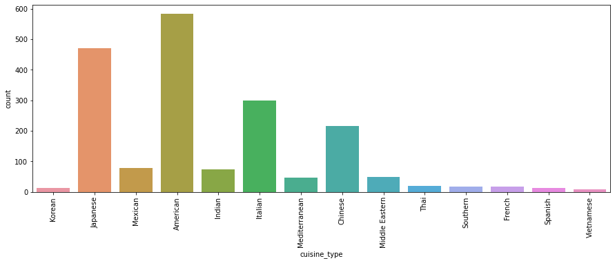

```python
plt.figure(figsize=(15,5)); #display the graph with the given size specifiations for the x-axis and y-axis respectively.

plt.xticks(rotation=90); #display the labels on the bins on the x-axis at 90 degrees to it.

sns.countplot(data=df,x='cuisine_type'); #Create a bar graph for the 'cuisine_type' column.
```

#### COST OF ORDER

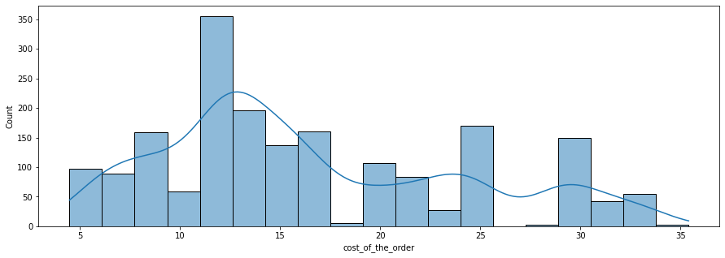

```python
#display the graph with the given size specifiations for the x-axis and y-axis respectively
plt.figure(figsize=(15,5));

#Create a histogram and kernel density estimation graph for 'cost_of_the_order'
sns.histplot(data=df, x='cost_of_the_order',kde=True);
```

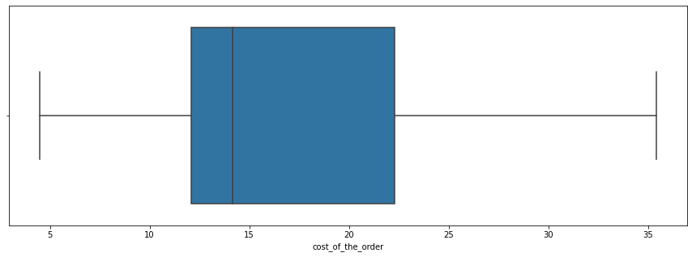

```python
plt.figure(figsize=(15,5)); #displays the graph with the given size specifiations for the x-axis and y-axis respectively.

sns.boxplot(data=df,x='cost_of_the_order'); #create a boxplot for the 'cost_of_the_order' column.
```

#### Observations:

1) The cost of order distribution shows a right (positive) skewness implying most the orders were relatively inexpensive.  
2) There are no outliers in the distribution hinting no extraordinary costs.  
3) 25% of orders cost at 12 dollars, the median cost is about 14 dollars and 75% of orders cost less than 22 dollars.  
4) The maximum cost recorded is 35 dollars while the minimum cost recorded is below 5 dollars.

#### DAY OF THE WEEK

```python
df['day_of_the_week'].nunique() #the number of unique values in the day of the week column
```

```
2
```

```python
df['day_of_the_week'].value_counts() # the frequency of each value in the column
```

```
Weekend    1351
Weekday     547
Name: day_of_the_week, dtype: int64
```

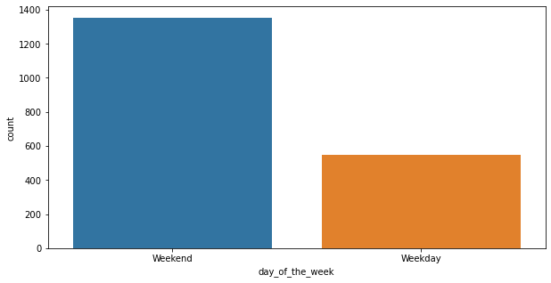

```python
plt.figure(figsize=(10,5)); #displays the graph with the given size specifiations for the x-axis and y-axis respectively.

sns.countplot(data=df,x='day_of_the_week'); #Create a bar graph for the 'day_of_the_week' column.
```

#### Observations:

1) Weekend and Weekday are the two categories in the day of the week column.  
2) The weekend showed more activity than the weekday, recording 1351 orders compared to the weekday's 547.

#### RATING

```python
df['rating'].value_counts(normalize=True) # view the relative frequency of each value in this column.
```

```
Not given    0.387777
5            0.309800
4            0.203372
3            0.099052
Name: rating, dtype: float64
```

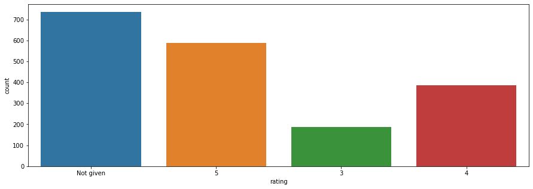

```python
plt.figure(figsize=(15,5)); #displays the graph with the given size specifiations for the x-axis and y-axis respectively.

sns.countplot(data=df,x='rating'); #Create a bar graph for the 'rating' column.
```

#### Observations:

3) Approximately 10% of orders had ratings of 3.

#### FOOD PREPARATION TIME

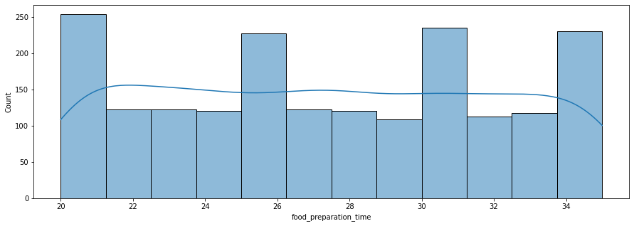

```python
#display the graph with the given size specifiations for the x-axis and y-axis respectively
plt.figure(figsize=(15,5));

#Create a histogram and kernel density estimation graph for 'food_preparation_time'
sns.histplot(data=df,x='food_preparation_time',kde=True);
```

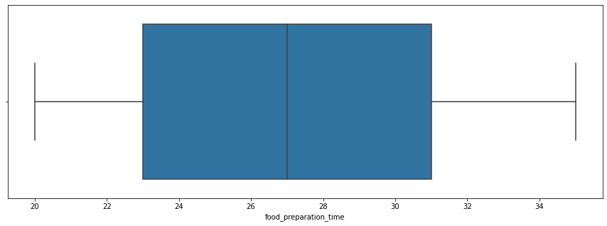

```python
plt.figure(figsize=(15,5)); #displays the graph with the given size specifiations for the x-axis and y-axis respectively.

sns.boxplot(data=df,x='food_preparation_time'); #create a boxplot for the 'food_preparation_time' column.
```

#### DELIVERY TIME

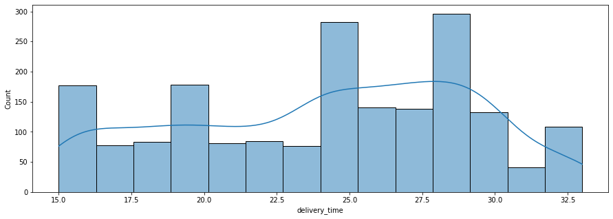

```python
#display the graph with the given size specifiations for the x-axis and y-axis respectively
plt.figure(figsize=(15,5));

#Create a histogram and kernel density estimation graph for 'delivery_time'
sns.histplot(data=df,x='delivery_time',kde=True);
```

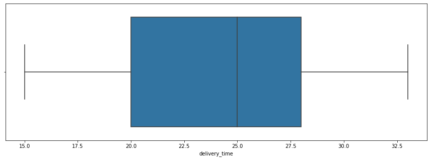

```python
plt.figure(figsize=(15,5)); #displays the graph with the given size specifiations for the x-axis and y-axis respectively.

sns.boxplot(data=df,x='delivery_time'); #create a boxplot for the 'delivery_time' column.
```

### **Question 7**: Which are the top 5 restaurants in terms of the number of orders received? [1 mark]

```python
df1 = df['restaurant_name'].value_counts() # return the frequency of each value in the 'restaurant_name' column.

df1.head() #return the first five rows
```

```
Shake Shack                  219
The Meatball Shop            132
Blue Ribbon Sushi            119
Blue Ribbon Fried Chicken     96
Parm                          68
Name: restaurant_name, dtype: int64
```

#### Observations:

The top five restaurants in terms of number of orders received are: SHAKE SHACK, THE MEATBALL SHOP, BLUE RIBBON SUSHI, BLUE RIBBON FRIED CHICKEN & PARM respectively.

### **Question 8**: Which is the most popular cuisine on weekends? [1 mark]

```python
df2 = df[df['day_of_the_week'] == 'Weekend'] #filter 'Weekend' rows from 'day_of_the_week' column

df2['cuisine_type'].value_counts() # return the frequency of each value in the 'cuisine_type' column.
```

```
American          415
Japanese          335
Italian           207
Chinese           163
Mexican            53
Indian             49
Mediterranean      32
Middle Eastern     32
Thai               15
French             13
Korean             11
Southern           11
Spanish            11
Vietnamese          4
Name: cuisine_type, dtype: int64
```

#### Observations:

The most popular cuisine on weekends is the American cuisine.

### **Question 9**: What percentage of the orders cost more than 20 dollars? [2 marks]

```python
df3 = df[df['cost_of_the_order'] > 20] # extrapolate rows with orders greater than 20 dollars in 'cost_of_the_order' column.

# divide extrapolated number of rows by total number of rows and multiply by 100
percentage = (df3.shape[0] / df.shape[0]) * 100

print('The percentage of orders greater than 20 dollars is', round(percentage,2)) # display result in two decimal places
```

```
The percentage of orders greater than 20 dollars is 29.24
```

#### Observations:

29.24% of total orders placed cost greater than 20 dollars.

### **Question 10**: What is the mean order delivery time? [1 mark]

```python
mean_del_time = df['delivery_time'].mean() #returns the average delivery time of the 'delivery_time' column.

print('The mean order delivery time is',round(mean_del_time,2)) # display result in two decimal places.
```

```
The mean order delivery time is 24.16
```

#### Observations:

Averagely, it took approximately 24 minutes to deliver dispatched orders.

### **Question 11:** The company has decided to give 20% discount vouchers to the top 3 most frequent customers. Find the IDs of these customers and the number of orders they placed. [1 mark]

```python
df['customer_id'].value_counts().head(3) #return relative frequency of values in 'customer_id' and display the first three rows
```

```
52832    13
47440    10
83287     9
Name: customer_id, dtype: int64
```

#### Observations:

Customers that qualify for this discount are: 52832, 47440 and 83287 respectively.

### **Question 12**: Perform a multivariate analysis to explore relationships between the important variables in the dataset. (It is a good idea to explore relations between numerical variables as well as relations between numerical and categorical variables) [10 marks]

#### CUISINE VS COST OF ORDER

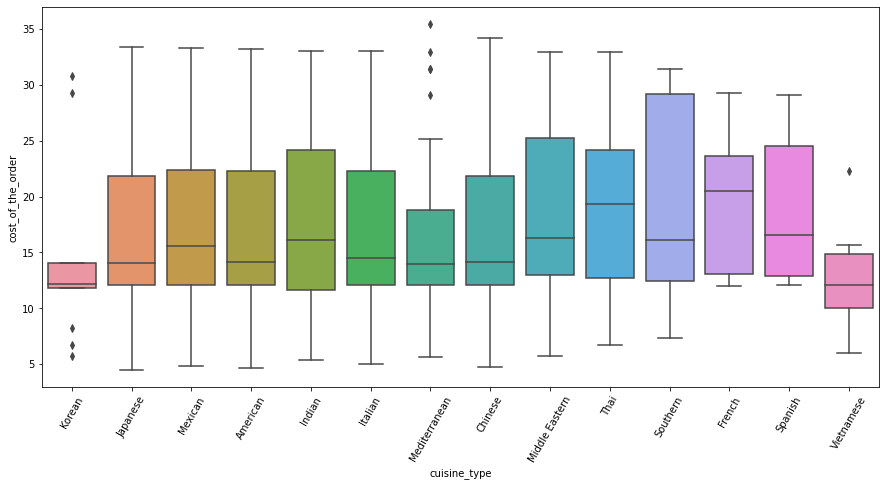

```python
# Explore the relationship between cost of the order and cuisine type
plt.figure(figsize=(15,7));
sns.boxplot(data=df, x = "cuisine_type", y = "cost_of_the_order");
plt.xticks(rotation = 60);
```

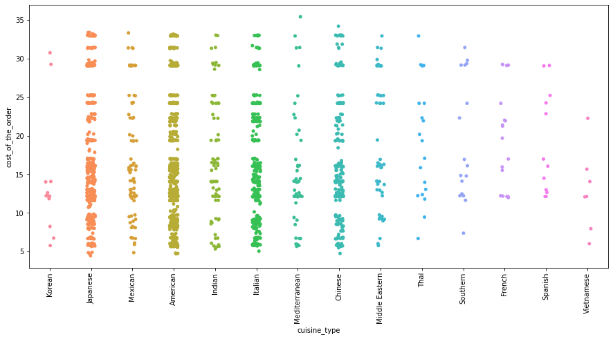

```python
plt.figure(figsize=(15,7));
sns.stripplot(data=df,x='cuisine_type',y='cost_of_the_order',jitter=True);
plt.xticks(rotation=90);
```

#### CUISINE TYPE VS COST OF ORDER BASED ON RATING

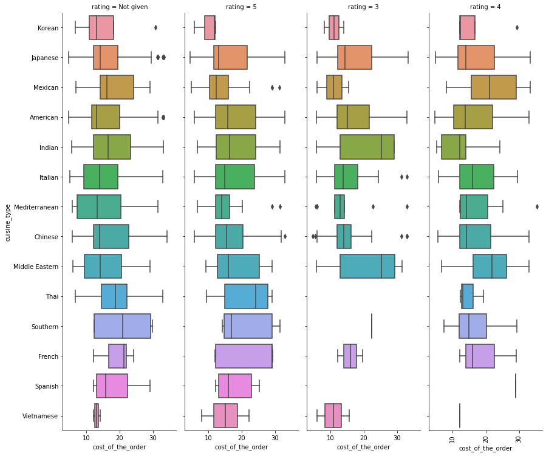

```python
sns.catplot(data=df,y='cuisine_type',x='cost_of_the_order',col='rating',kind='box',height=10.5,aspect=0.3);
plt.xticks(rotation=90);
```

#### Observation:

The average cost of the cuisines are fairly consistent in the rating categories indicating that customers did not rate orders based on the costs.

#### CUISINE TYPE VS COST OF ORDER BASED ON DAY OF THE WEEK

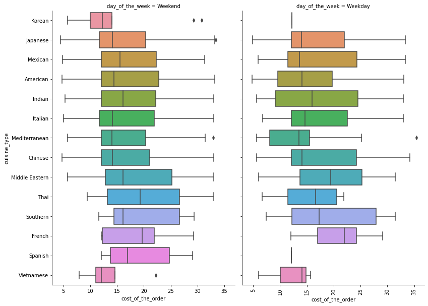

```python
sns.catplot(data=df,y='cuisine_type',x='cost_of_the_order',col='day_of_the_week',kind='box',height=8.5,aspect=0.7);
plt.xticks(rotation=90);
```

#### CUISINE VS FOOD PREPARATION TIME

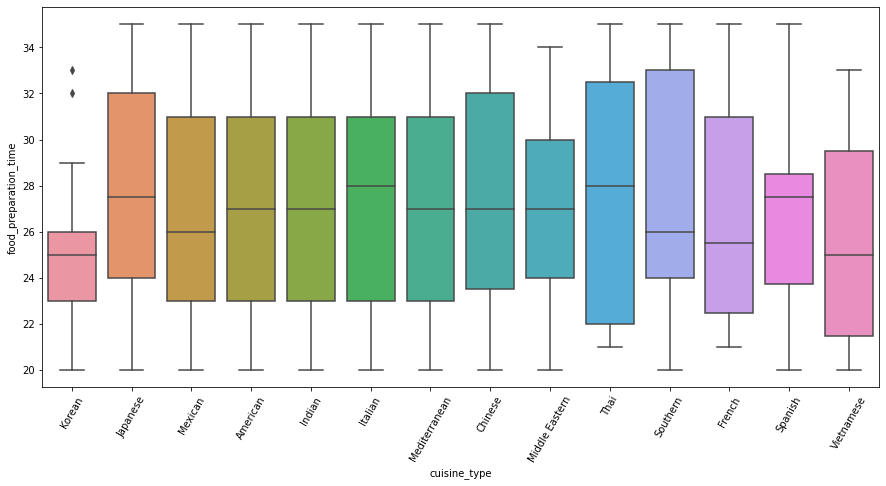

```python
# Explore the relationship between cuisine type and food preparation time.
plt.figure(figsize=(15,7));
sns.boxplot(data=df, x='cuisine_type', y='food_preparation_time');
plt.xticks(rotation = 60);
```

#### CUISINE TYPE VS FOOD PREPARATION TIME IN TERMS OF DAYS OF THE WEEK

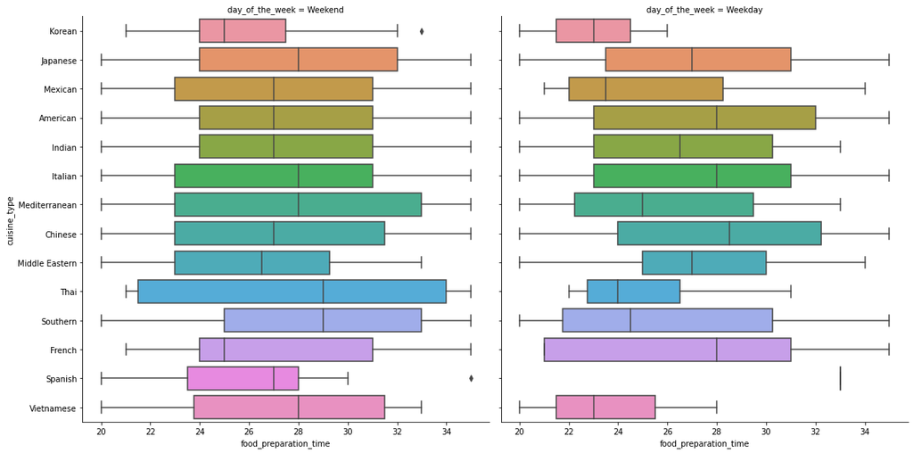

```python
sns.catplot(data=df,y='cuisine_type',x='food_preparation_time',col='day_of_the_week',kind='box',height=8,aspect=1);
```

#### CUISINE TYPE VS FOOD PREPARATION TIME BASED ON RATING

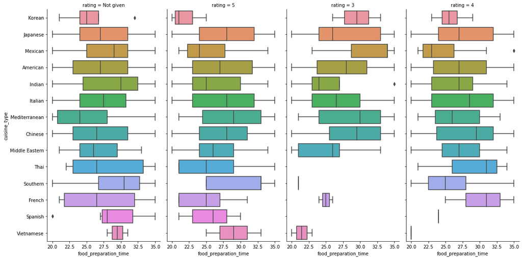

```python
sns.catplot(data=df,y='cuisine_type',x='food_preparation_time',col='rating',kind='box',height=8,aspect=0.5);
```

#### CUISINE VS DELIVERY TIME

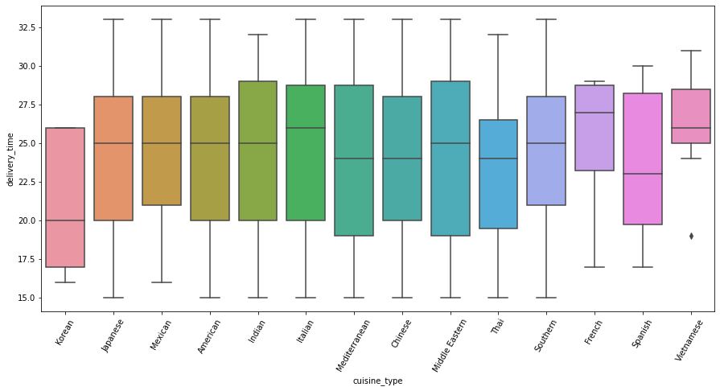

```python
# Explore the relationship between cuisine type and delivery time.
plt.figure(figsize=(15,7));
sns.boxplot(data=df, x='cuisine_type', y='delivery_time');
plt.xticks(rotation = 60);
```

#### CUISINE TYPE VS DELIVERY TIME IN TERMS OF RATING

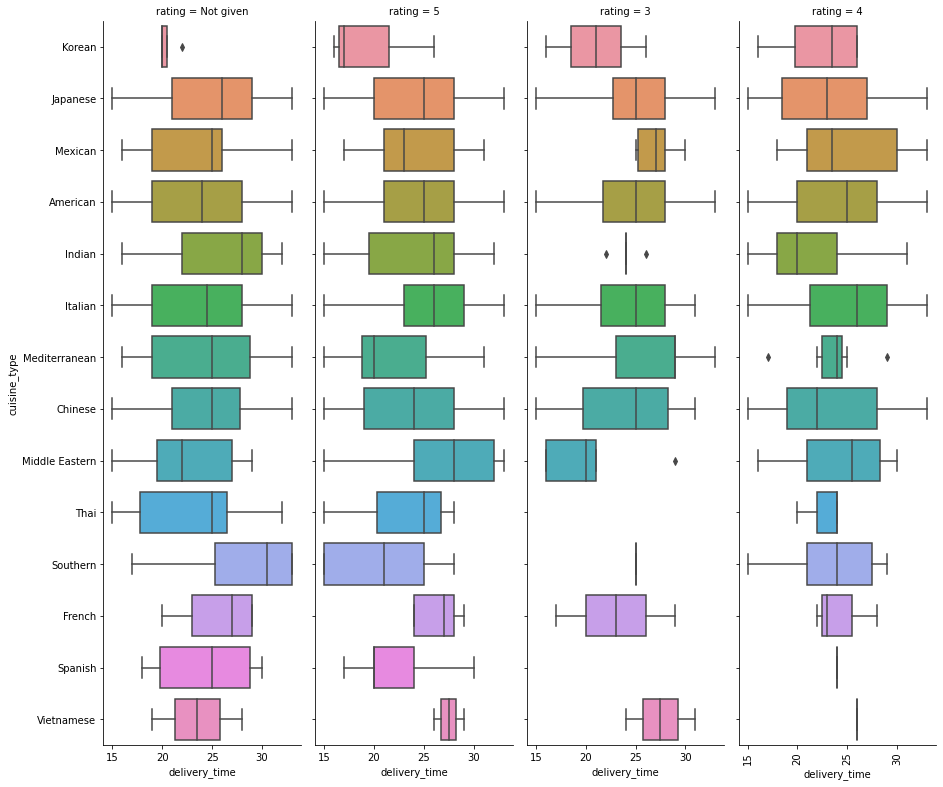

```python
sns.catplot(data=df,y='cuisine_type',x='delivery_time',col='rating',kind='box',height=11,aspect=0.3);
plt.xticks(rotation=90);
```

#### Observations:

The top four most popular cuisines took a relatively longer delivery time but received a high rating indicating customers rated based on other priorities.

#### CUISINE TYPE VS RATING

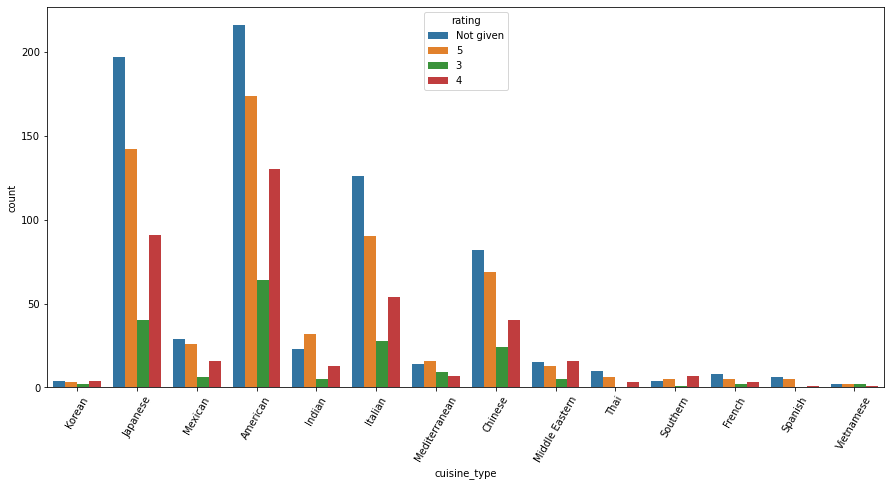

```python
# Relationship between cuisine type and rating
plt.figure(figsize=(15,7));
sns.countplot(data=df,x='cuisine_type',hue='rating');
plt.xticks(rotation=60);
```

#### Observations:

1) America,Japanese,Italian and Chinese recorded the highest rating counts possibly due to the high number of orders placed for them.  
2) The same restaurants received the highest count of perfect rating with American cuisine being the highest; Japanese, Italian and Chinese followed respectively.  
3) The same restaurants received the highest count of rating of 4 with American cuisine being the highest; Japanese, Italian and Chinese followed respectively.  
4) The rating of 3 however showed the same order in terms of count.  
5) This order is indicative of the quantity of the total count rather than the cuisine type since the same cuisine (American) recorded high counts for the high ratings.

#### DAY OF THE WEEK VS DELIVERY TIME

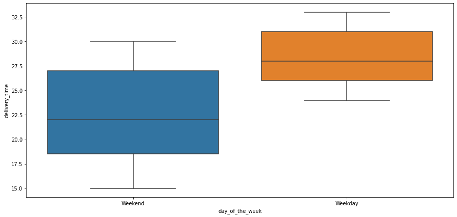

```python
# Relationship between day of the week and delivery time
plt.figure(figsize=(15,7));
sns.boxplot(data=df, x='day_of_the_week',y='delivery_time');
```

#### Observations:

1) The average delivery time on weekends is 22 minutes and 28 minutes on weekdays.From the distribution above, implying faster delivery on weekends than on weekdays.  
2) Also, the least time it takes to deliver on weekdays is significantly higher than on weekends possibly explaining the popularity of orders on weekends.  
3) The maximum time for delivery on weekends is also lower than on weekdays further confirming faster delivery on weekends than on weekdays.  
4) There are no outliers in the distribution for both periods of the week.  
5) Both periods however do show a right skewed distribution.

#### DAY OF THE WEEK VS CUISINE TYPE

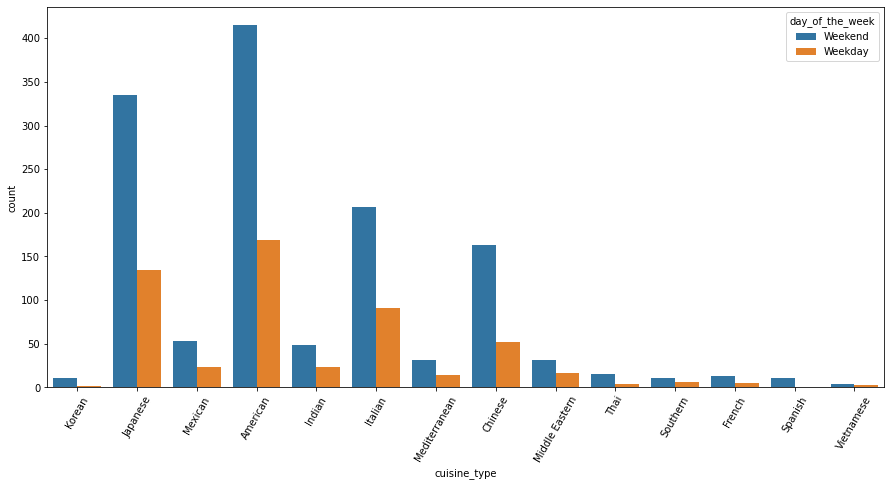

```python
# Relationship between day of the week and cuisine type.
plt.figure(figsize=(15,7));
sns.countplot(data=df, hue='day_of_the_week',x='cuisine_type');
plt.xticks(rotation=60);
```

#### Observations:

The four most popular cuisines (American,Japanese,Italian,Chinese respectively) record the highest orders for weekends and weekdays in the same order.

#### DAY OF THE WEEK VS FOOD PREPARATION TIME

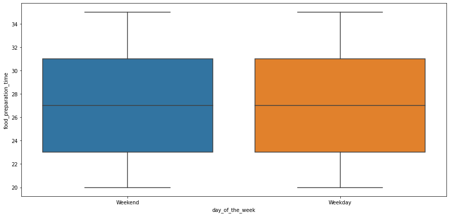

```python
# Relationship between day of the week and food preparation time
plt.figure(figsize=(15,7));
sns.boxplot(data=df, x='day_of_the_week',y='food_preparation_time');
```

#### Observations:

1) Both periods show a similar distribution for the given variables.  
2) Both distributions do not show any significant skewness.  
3) There are no outliers in the distribution.  
4) The minimum and maximum preparation time is 20 and 35 minutes respectively for both periods.  
5) The average preparation time for both periods is 27 minutes.

#### DAY OF THE WEEK VS COST OF THE ORDER

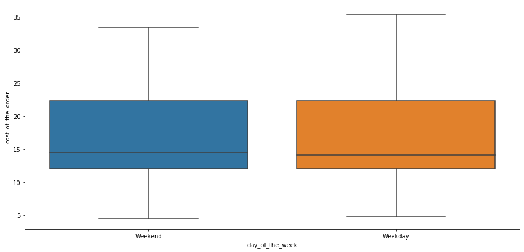

```python
plt.figure(figsize=(15, 7));
sns.boxplot(data=df,x='day_of_the_week',y='cost_of_the_order');
```

#### RATING VS DELIVERY TIME

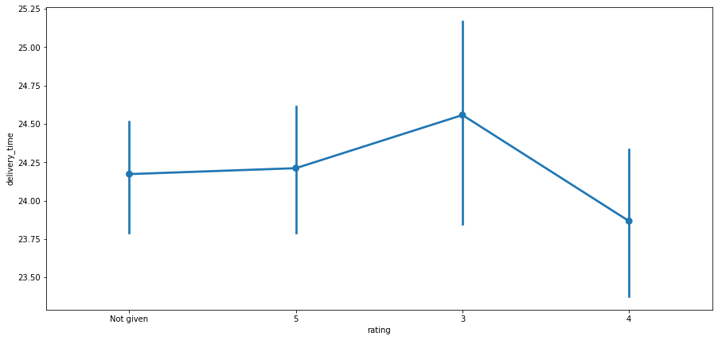

```python
# Relationship between rating and delivery time
plt.figure(figsize=(15, 7))
sns.pointplot(x = 'rating', y = 'delivery_time', data = df)
plt.show()
```

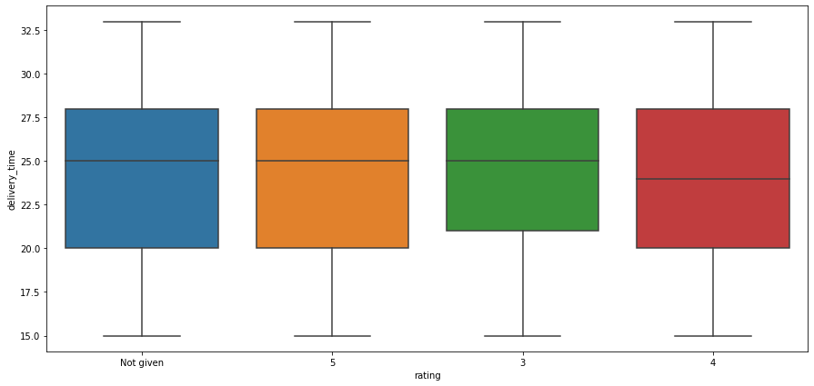

```python
# Relationship between rating and delivery time
plt.figure(figsize=(15, 7))
sns.boxplot(x= 'rating', y= 'delivery_time', data = df)
plt.show()
```

#### RATING VS FOOD PREPARATION TIME

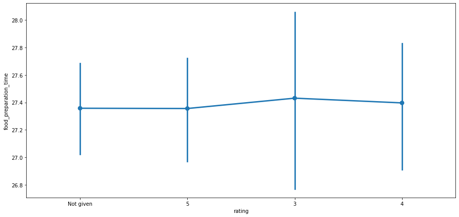

```python
# Relationship between rating and food preparation time
plt.figure(figsize=(15, 7));
sns.pointplot(data=df,x='rating',y='food_preparation_time');
```

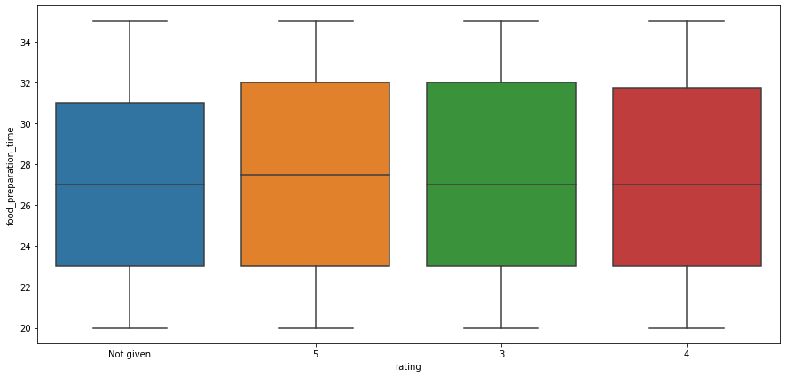

```python
# Relationship between rating and food preparation time
plt.figure(figsize=(15, 7));
sns.boxplot(x= 'rating', y= 'food_preparation_time', data = df);
plt.show();
```

#### RATING VS COST OF ORDER

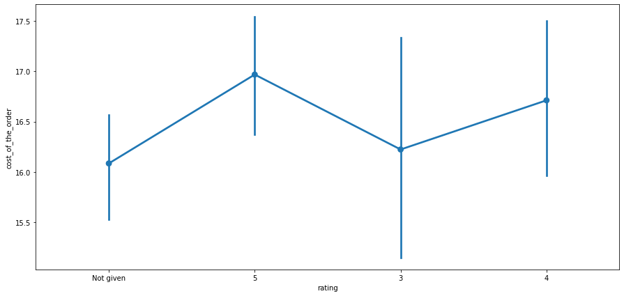

```python
# Relationship between rating and cost of the order
plt.figure(figsize=(15, 7))
sns.pointplot(data=df,x='rating',y='cost_of_the_order');
```

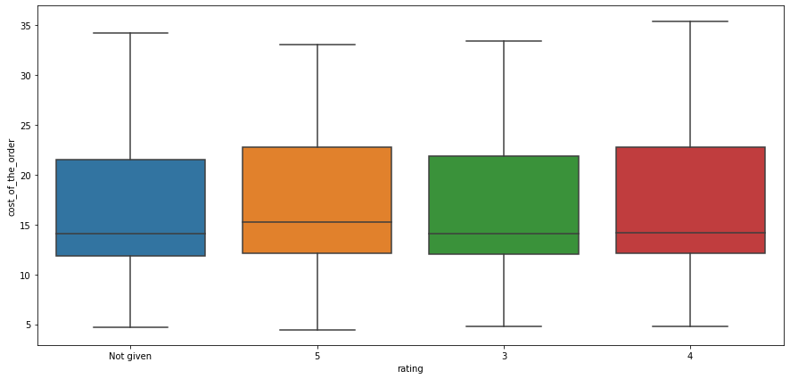

```python
# Relationship between rating and food preparation time
plt.figure(figsize=(15, 7));
sns.boxplot(x= 'rating', y= 'cost_of_the_order', data = df);
plt.show();
```

#### COST OF ORDER VS DELIVERY TIME

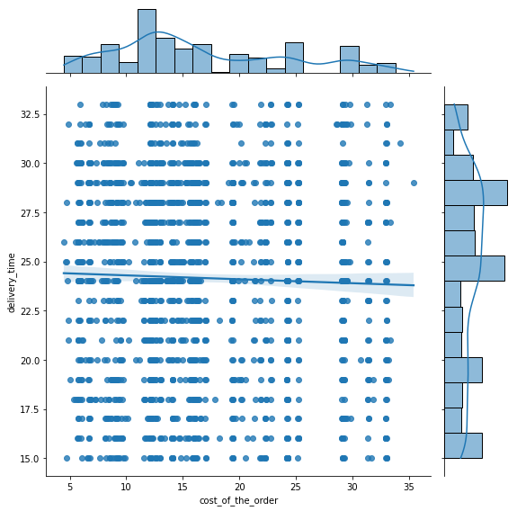

```python
# histogram and linear model plot realtionship between cost of order and delivery time
sns.jointplot(data = df, x = 'cost_of_the_order', y = 'delivery_time', kind = 'reg',height= 8);
```

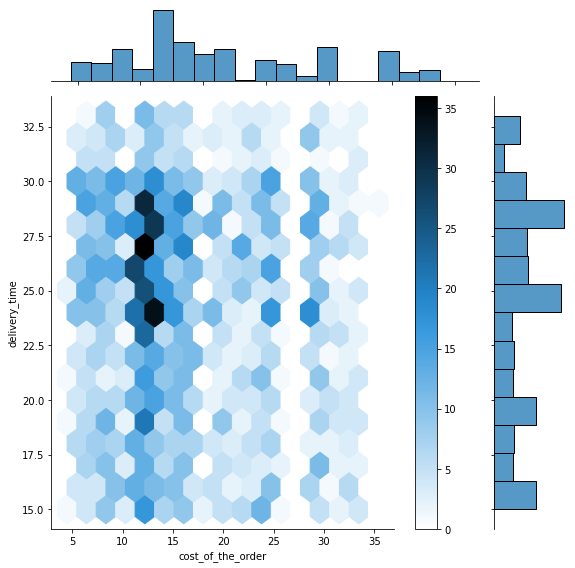

```python
# histogram and linear model plot realtionship between cost of order and delivery time
sns.jointplot(data = df, x = 'cost_of_the_order', y = 'delivery_time', kind = 'hex',height= 8);
plt.colorbar();
```

#### Observations:

The cost of the order and the delivery time do not show any strong correlation as seen in the slope of the line. However, most of the orders that were delivered between 23-28 minutes wereless than 15 dollars hence a right skewed histogram distribution.

#### COST OF ORDER VS FOOD PREPARATION TIME

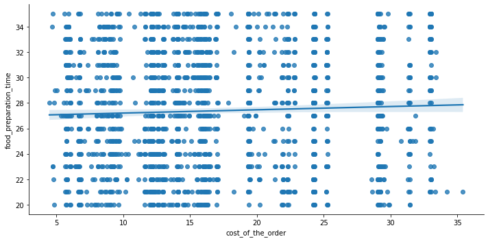

```python
#explore correlation between cost and food prep time
sns.lmplot(data=df,x='cost_of_the_order',y='food_preparation_time',height=5,aspect=2);
```

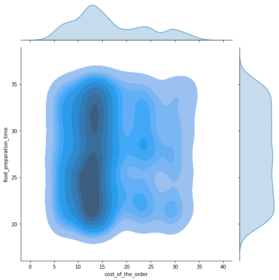

```python
sns.jointplot(data=df,x='cost_of_the_order',y='food_preparation_time',height=8,kind='kde',fill=True);
```

#### Observations:

There is no significant correlation between these two variables.  
There is a significant concentration of orders between 11-13 dollars which were prepared in the 20-25 minutes range.

#### FOOD PREPARATION TIME VS DELIVERY TIME

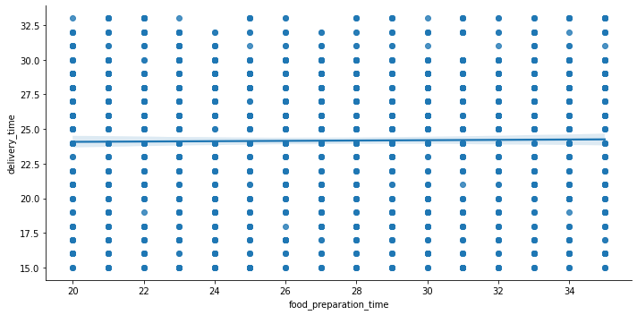

```python
#explore correlation between food preparation time and delivery time
sns.lmplot(data=df,x='food_preparation_time',y='delivery_time',height=5,aspect=2);
```

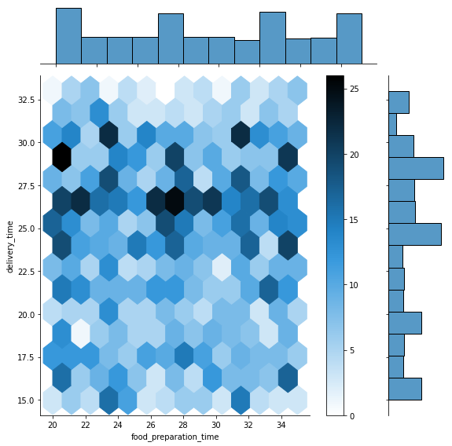

```python
sns.jointplot(data=df,y='delivery_time',x='food_preparation_time',height=8,kind='hex');
plt.colorbar();
```

#### Observations:

There is no significant correlation between these two variables and there is a spread in high counts for orders in the given food preparation timeframe. Hence the spread of dark areas.

#### CORRELATION AMONG VARIABLES

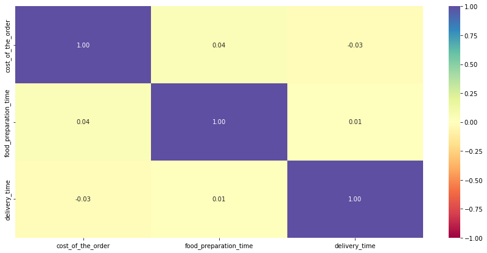

```python
#Explore realtionship between numerical variables
col_list = ['cost_of_the_order', 'food_preparation_time', 'delivery_time']
plt.figure(figsize=(15, 7));
sns.heatmap(df[col_list].corr(), annot=True, vmin=-1, vmax=1, fmt=".2f", cmap="Spectral");
plt.show();
```

#### Observations:

There is no significant correlation between the variables. These parameters are independent of each other.

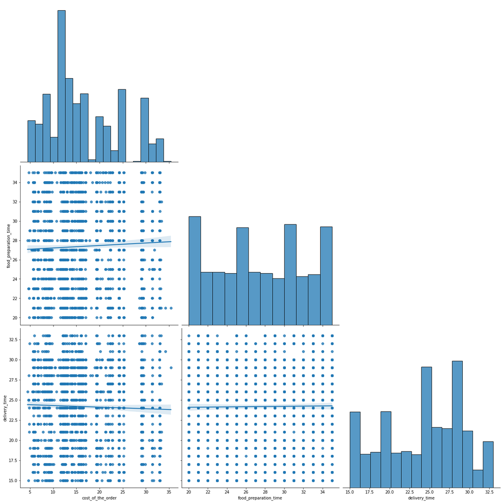

```python
#further explore relationship between numerical variables.
sns.pairplot(data=df[['cost_of_the_order','food_preparation_time','delivery_time']],height=6,corner=True,kind='reg');
```

#### Observations:

There is no visible correlation amongst the variables as seen in the distribution above.

### **Question 13:** The company wants to provide a promotional offer in the advertisement of the restaurants. The condition to get the offer is that the restaurants must have a rating count of more than 50 and the average rating should be greater than 4. Find the restaurants fulfilling the criteria to get the promotional offer. [3 marks]

```python
df_rated = df[df['rating'] != 'Not given'].copy() # create new dataframe with 'Not given' values in rating column filtered out.

df_rated['rating'] = df_rated['rating'].astype('int') #convert the dataframe dtype to integer

df_rating_count = df_rated.groupby(['restaurant_name'])['rating'].count().sort_values(ascending = False).reset_index()

# create column consisting restaurants with rating count greater than 50
rest_names = df_rating_count[df_rating_count['rating'] > 50]['restaurant_name']

# Filter to get the data of restaurants that have rating count more than 50
df_mean_4 = df_rated[df_rated['restaurant_name'].isin(rest_names)].copy()

df_mean_4.groupby(['restaurant_name'])['rating'].mean().sort_values(ascending = False).reset_index().dropna()
```

|  | restaurant_name | rating |
| --- | --- | --- |
| 0 | The Meatball Shop | 4.511905 |
| 1 | Blue Ribbon Fried Chicken | 4.328125 |
| 2 | Shake Shack | 4.278195 |
| 3 | Blue Ribbon Sushi | 4.219178 |

#### Observations:

Four restaurants fulfill the criteria to get the promotional offer. They are THE MEATBALL SHOP, BLUE RIBBON FRIED CHICKEN, SHAKE SHACK, BLUE RIBBON SUSHI.

### **Question 14:** The company charges the restaurant 25% on the orders having cost greater than 20 dollars and 15% on the orders having cost greater than 5 dollars. Find the net revenue generated by the company across all orders. [3 marks]

```python
compute_rev = 0
for i in df['cost_of_the_order']:
    if i > 20:
        compute_rev = compute_rev + (0.25 * i) # multiply orders greater than 20 dollars by 25%
    elif 5 < i < 20:
        compute_rev = compute_rev + (0.15 * i) # multiply orders greater than 5 dollars but less than 20 dollars by 15%

print("{:.2f}".format(compute_rev)) # print result to two decimal places.
```

```
6166.30
```

#### Observations:

The total revenue generated by the company across all the orders is 6166.30 dollars

#### EXPLORE REVENUE GENERATED BY THE RESTAURANTS

```python
df.groupby(['restaurant_name'])['cost_of_the_order'].sum().sort_values(ascending = False).head(14)
```

```
restaurant_name
Shake Shack                      3579.53
The Meatball Shop                2145.21
Blue Ribbon Sushi                1903.95
Blue Ribbon Fried Chicken        1662.29
Parm                             1112.76
RedFarm Broadway                  965.13
RedFarm Hudson                    921.21
TAO                               834.50
Han Dynasty                       755.29
Blue Ribbon Sushi Bar & Grill     666.62
Rubirosa                          660.45
Sushi of Gari 46                  640.87
Nobu Next Door                    623.67
Five Guys Burgers and Fries       506.47
Name: cost_of_the_order, dtype: float64
```

#### Observations:

1) Shake Shack recorded the highest revenue with 3579.53 dollars.  
2) Only SHAKE SHACK,THE MEATBALL SHOP,BLUE RIBBON SUSHI,BLUE RIBBON FRIED CHICKEN AND PARM racked revenues greater than 1000 dollars.  
3) These five restaurants received the most orders hence a possible reason for their high revenues.

### **Question 15:** The company wants to analyze the total time required to deliver the food. What percentage of orders take more than 60 minutes to get delivered from the time the order is placed? (The food has to be prepared and then delivered.) [2 marks]

```python
df['total_time'] = df['food_preparation_time'] + df['delivery_time'] #create column consisting total time for both conditions.

prep_count = df['total_time'].count()  #number of rows in the total time column

prep_over_60 = df['total_time'][df['total_time']> 60].count() #number of rows with values over 60

percent_prep = (prep_over_60 / prep_count) * 100 #divide both rows and multiply by 100

print(round(percent_prep,2))
```

```
10.54
```

#### Observations:

Observations: About 10.5% of orders take more than 60 minutes to be prepared and delivered.

### **Question 16:** The company wants to analyze the delivery time of the orders on weekdays and weekends. How does the mean delivery time vary during weekdays and weekends? [2 marks]

```python
df.groupby(['day_of_the_week'])['delivery_time'].mean()
```

```
day_of_the_week
Weekday    28.340037
Weekend    22.470022
Name: delivery_time, dtype: float64
```

#### Observations:

It takes at least 28 minutes to deliver orders on weekdays and about 22 minutes to deliver on weekends indicating a keen difference in delivery times. This is probably due to less traffic on delivery routes during the weekends.

### Conclusion and Recommendations

### **Question 17:** What are your conclusions from the analysis? What recommendations would you like to share to help improve the business? (You can use cuisine type and feedback ratings to drive your business recommendations.) [6 marks]

### Conclusions:

- The weekend period received more orders than the weekdays possibly because there is generally more or gatherings on the weekend than on the weekday.
- The data showed a fairly consistent food preparation time for the various cuisines. However, the varied delivery times significantly impacted the overall time it took to complete an order (from order receipt to delivery).
- There are a varied number of cuisines to reach a diverse market. However, some cuisines were more popular amongst the customers than others. 10 cuisines did not record orders greater than 100.
- Also, the distribution of restaurants were biased towards a few. Some restaurants received more orders than others. This could be due to food quality, general popularity in the market or a certain demographic, etc. Further investigation could be done to learn more.
- Delivery time was generally shorter on weekends than on weekdays perhaps due to less traffic on delivery routes or fewer delivery agents available on weekdays.
- The customer behavior calculated the ratio of order id to customer id. This aimed to show the average number of times a customer placed an order. A result less than 2 indicates that there were a significant number of customers that made orders only once.
- Even though a significant number of orders received rating of 5, 38% of orders did not receive ratings. This is a significant number and could have impacted the overall rating distribution if available.
- The ratings were not influenced by the food preparation time, delivery time or the cost of the orders. Customers possibly rated based on other priorities like taste, quality of service, etc.
- There are no extraordinarily high prices for the menus. However, the mean price is quite biased towards the cheaper side perhaps giving an insight into the nature of the customer base or the demographic distribution. Perhaps orders originate more from students who are likely to purchase relatively cheaper meals.
- The cost of the order does not affect the delivery time or food preparation time. There is no bias in this regard. Customers are treated equally.
- Some cuisines appear to be favorable amongst the customers as they were ordered more and given better ratings.
- A Significant number of relatively cheaper cuisines received low ratings indicating customers did not give ratings based on the cost.

### Recommendations:

- To boost the number of orders on weekdays, special packages like discounts, free delivery, bonuses,etc. could be designed to encourage buying during this period.
- To further confirm the distributions in the weekday and weekends, Foodhub can check for hoildays or special ceremonies in those periods as they could have impacted orders and not necessarily be a trend.
- Traffic congestion and delivery availabilty could be reasons that impact delivery times on weekdays. More delivery routes could be explored to escape the congestion or faster modes of delivery could be employed. Also, more delivery agents could be employed to enhance faster delivery.
- The uneven distribution of the different cuisines could be due to the the demograhy, food quality, branding, etc. Further investigation into these should be conducted to learn more.
- A similar investigation should be made to learn more about the popularity of some restaurants compared to others.
- A significant number of clients made an order only once. Foodhub can insist on feeback from such customers by reaching out directly. For consistent customers, rewards could be given to encourage them and stronger marketing and advertisement strategies developed to introduce more products to them.
- Foodhub can reach out to customers who received orders without ratings to understand their reasons for doing so.